# MIS 306 Data Analysis: Forecasting Homework 1

2025-03-20

Batuhan Karaköy - #3

# Boeing Company Stock Price Series

In this assignment I have done some time series analysis for Boeing Company stock prices.

## Intstalling Libraries

```r
library(quantmod)
library(xts)
library(lubridate)
```

## Loading the Data

```r
load("djdata.RData")
```

## Looking for column names

```r
colnames(djdata)
```

```
##  [1] "MMM"  "AXP"  "AMGN" "AMZN" "AAPL" "BA"   "CAT"  "CVX"  "CSCO" "KO"
## [11] "DIS"  "GS"   "HD"   "HON"  "IBM"  "JNJ"  "JPM"  "MCD"  "MRK"  "MSFT"
## [21] "NKE"  "NVDA" "PG"   "CRM"  "SHW"  "TRV"  "UNH"  "VZ"   "V"    "WMT"
```

```r
colnames(djdata.df)
```

```
##  [1] "Date" "MMM"  "AXP"  "AMGN" "AMZN" "AAPL" "BA"   "CAT"  "CVX"  "CSCO"
## [11] "KO"   "DIS"  "GS"   "HD"   "HON"  "IBM"  "JNJ"  "JPM"  "MCD"  "MRK"
## [21] "MSFT" "NKE"  "NVDA" "PG"   "CRM"  "SHW"  "TRV"  "UNH"  "VZ"   "V"
## [31] "WMT"
```

## Removing IBM from data & Selecting BA from data

```r
symbols <- colnames(djdata)
symbols
```

```
##  [1] "MMM"  "AXP"  "AMGN" "AMZN" "AAPL" "BA"   "CAT"  "CVX"  "CSCO" "KO"
## [11] "DIS"  "GS"   "HD"   "HON"  "IBM"  "JNJ"  "JPM"  "MCD"  "MRK"  "MSFT"
## [21] "NKE"  "NVDA" "PG"   "CRM"  "SHW"  "TRV"  "UNH"  "VZ"   "V"    "WMT"
```

```r
symbols[-15]
```

```
##  [1] "MMM"  "AXP"  "AMGN" "AMZN" "AAPL" "BA"   "CAT"  "CVX"  "CSCO" "KO"
## [11] "DIS"  "GS"   "HD"   "HON"  "JNJ"  "JPM"  "MCD"  "MRK"  "MSFT" "NKE"
## [21] "NVDA" "PG"   "CRM"  "SHW"  "TRV"  "UNH"  "VZ"   "V"    "WMT"
```

```r
set.seed(20022025)
sample(symbols[-15], 16)
```

```
##  [1] "JNJ"  "MSFT" "BA"   "AXP"  "AAPL" "HD"   "DIS"  "MMM"  "UNH"  "NKE"
## [11] "AMGN" "MCD"  "TRV"  "VZ"   "GS"   "JPM"
```

```r
set.seed(20022025)
lst <- sample(symbols[-15], 16)

lst[3]
```

```
## [1] "BA"
```

```r
djdata[,lst[3]]
```

```
##                   BA
## 2007-01-03  64.40572
## 2007-01-04  64.66572
## 2007-01-05  64.39128
## 2007-01-08  64.23962
## 2007-01-09  63.56065
## 2007-01-10  64.47794
## 2007-01-11  64.16737
## 2007-01-12  63.65453
## 2007-01-16  63.56065
## 2007-01-17  64.16013
##        ...
## 2025-03-06 158.42999
## 2025-03-07 154.17999
## 2025-03-10 148.14999
## 2025-03-11 154.06000
## 2025-03-12 158.80000
## 2025-03-13 159.32001
## 2025-03-14 161.81000
## 2025-03-17 161.85001
## 2025-03-18 161.57001
## 2025-03-19 172.62000
```

```r
getSymbols(lst[3])
```

```
## [1] "BA"
```

## Looking for the first and last few observations of data

```r
head(BA)
```

```
##            BA.Open BA.High BA.Low BA.Close BA.Volume BA.Adjusted
## 2007-01-03   88.90   90.30  88.45    89.17   4871700    64.40572
## 2007-01-04   88.34   89.83  87.01    89.53   2718900    64.66573
## 2007-01-05   89.78   90.00  88.50    89.15   3285900    64.39129
## 2007-01-08   88.61   89.41  87.56    88.94   2989000    64.23959
## 2007-01-09   88.93   89.71  87.56    88.00   4193800    63.56063
## 2007-01-10   88.04   89.34  88.00    89.27   3955200    64.47792
```

```r
tail(BA)
```

```
##            BA.Open BA.High BA.Low BA.Close BA.Volume BA.Adjusted
## 2025-03-12  157.00  159.54 153.61   158.80   8706900      158.80
## 2025-03-13  159.22  161.74 157.25   159.32   5701600      159.32
## 2025-03-14  160.92  162.32 159.20   161.81   5215100      161.81
## 2025-03-17  160.50  162.77 159.62   161.85   5602700      161.85
## 2025-03-18  161.44  162.23 158.79   161.57   4195200      161.57
## 2025-03-19  165.32  174.20 165.00   172.62  14098800      172.62
```

## Plot for opening, closing prices, high and low values and the volume

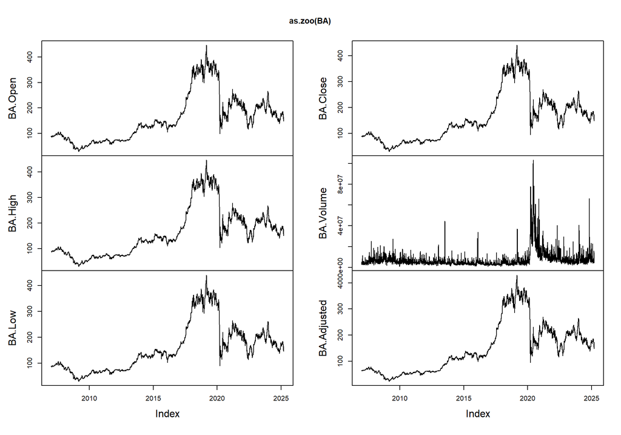

```r
plot(as.zoo(BA))
```

We see that the BA.Open, BA.High, BA.Low, and BA.Close graphs display stock prices at different points, with clear volatility and a big drop around 2020. The BA.Volume graph highlights trading activity, with noticeable spikes that likely indicate significant events or decisions made by investors. The BA.Adjusted graph shows the adjusted closing prices, which take dividends and stock splits into account, giving a more accurate picture of value.

## Line Chart (2007 - 2025)

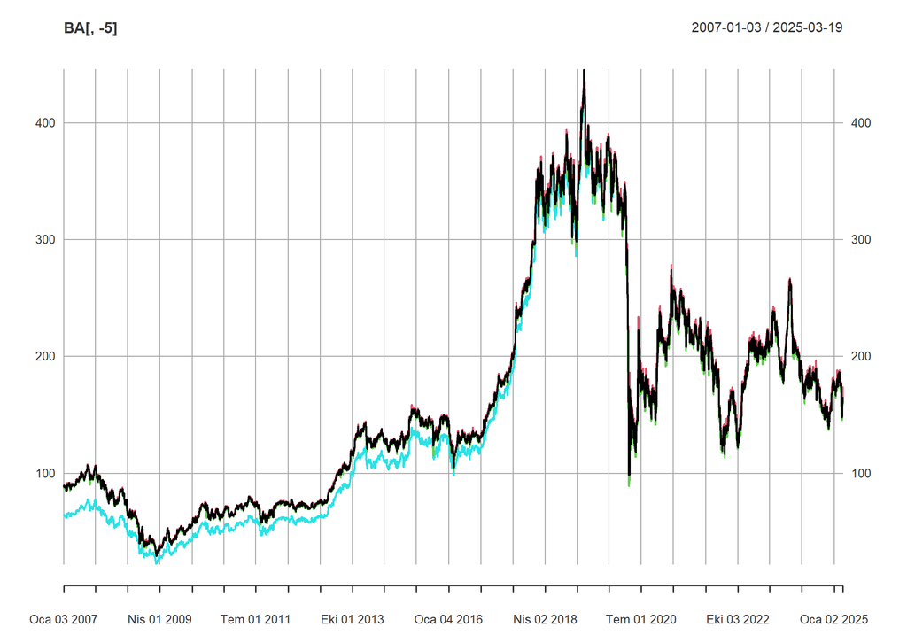

```r
plot(BA[,-5])
```

When we look at this line graph we can see that it remains stable until 2016, followed by a sharp rise peaking in 2019. A sudden drop in 2020 that I assume its because of the pandemics. After 2021, the values fluctuate but stabilize at a lower level than the peak.

## Financial Data

```r
# First few days without labelling.
head(wday(index(BA), label=F))
```

```
## [1] 4 5 6 2 3 4
```

```r
# First few days with labelling..
head(wday(index(BA), label=T))
```

```
## [1] Çar Per Cum Pzt Sal Çar
## Levels: Paz < Pzt < Sal < Çar < Per < Cum < Cmt
```

```r
# result is factor object..
str(head(wday(index(BA), label=T)))
```

```
##  Ord.factor w/ 7 levels "Paz"<"Pzt"<"Sal"<..: 4 5 6 2 3 4
```

```r
is.factor(head(wday(index(BA), label=T)))
```

```
## [1] TRUE
```

```r
# Get the first few days as character (instead of factor)
paste(head(wday(index(BA), label=T)))
```

```
## [1] "Çar" "Per" "Cum" "Pzt" "Sal" "Çar"
```

```r
# days of year
yday(Sys.Date())
```

```
## [1] 79
```

```r
yday(index(first(BA["200303"], "1 week")))
```

```
## numeric(0)
```

```r
# days of quarter
qday(Sys.Date())
```

```
## [1] 79
```

```r
head(qday(index(BA)))
```

```
## [1]  3  4  5  8  9 10
```

```r
quarter(Sys.Date()) # quarter of the date
```

```
## [1] 1
```

```r
# days of month
head(mday(index(BA)))
```

```
## [1]  3  4  5  8  9 10
```

```r
# month of first few obs.
head(month(index(BA)))
```

```
## [1] 1 1 1 1 1 1
```

```r
# Convert to monthly data using to.monthly() function. Then get the first few months
head(month(index(to.monthly(BA)), label=T))
```

```
## [1] Oca Şub Mar Nis May Haz
## 12 Levels: Oca < Şub < Mar < Nis < May < Haz < Tem < Ağu < Eyl < ... < Ara
```

```r
# Just names only..
paste(head(month(index(to.monthly(BA)), label=T)))
```

```
## [1] "Oca" "Şub" "Mar" "Nis" "May" "Haz"
```

```r
# last weekdays of months and of course weekdaysdate
last_weekday_o_month <- function(dx) {
  ave(
  paste(wday(dx, label=T, abbr=F)),
  paste(month(dx, label=T, abbr = F)),
  FUN = function(x) tail(x[ !(x %in% c("Saturday","Sunday")) ], 1)
  )
}

last_weekdaydate_o_month <- function(dx){
  ave(
    dx,
#     paste(month(dx, label=T, abbr = F)),
    month(dx, label=T),
    year(dx),
    FUN = function(x) tail(x[ !(wday(x, label=T, abbr=F) %in% c("Saturday","Sunday")) ], 1)
  )
}

# Get the last 25 end of months weekdays Adjusted close value..

Ad(BA[tail(unique(last_weekdaydate_o_month(index(BA))), 15),])
```

```
##            BA.Adjusted
## 2024-01-31      211.04
## 2024-02-29      203.72
## 2024-03-28      192.99
## 2024-04-30      167.84
## 2024-05-31      177.61
## 2024-06-28      182.01
## 2024-07-31      190.60
## 2024-08-30      173.74
## 2024-09-30      152.04
## 2024-10-31      149.31
## 2024-11-29      155.44
## 2024-12-31      177.00
## 2025-01-31      176.52
## 2025-02-28      174.63
## 2025-03-19      172.62
```

## Close, Adjusted Close, Day-of-week

```r
ba <- Ad(BA)

# Get Mondays
head(ba[wday(index(ba))==2])
```

```
##            BA.Adjusted
## 2007-01-08    64.23959
## 2007-01-22    61.82721
## 2007-01-29    61.75497
## 2007-02-05    65.52527
## 2007-02-12    64.67619
## 2007-02-26    64.48043
```

```r
# Mondays..
wday(head(ba[wday(index(ba))==2]), label=T)
```

```
## [1] Pzt Pzt Pzt Pzt Pzt Pzt
## Levels: Paz < Pzt < Sal < Çar < Per < Cum < Cmt
```

```r
# Fridays..
wday(head(ba[wday(index(ba))==6]), label=T)
```

```
## [1] Cum Cum Cum Cum Cum Cum
## Levels: Paz < Pzt < Sal < Çar < Per < Cum < Cmt
```

```r
# Get return series (cont. compounding, log(xt/xt-1)=log(xt)-log(xt-1))
ba.ret <- diff(log(ba))

# Mondays returns..
head(ba.ret[wday(index(ba.ret))==2])
```

```
##              BA.Adjusted
## 2007-01-08 -0.0023586143
## 2007-01-22 -0.0347847782
## 2007-01-29  0.0008198585
## 2007-02-05  0.0074130752
## 2007-02-12 -0.0089292116
## 2007-02-26 -0.0150661734
```

```r
# Data and return series together..
head(merge(ba, ba.ret))
```

```
##            BA.Adjusted BA.Adjusted.1
## 2007-01-03    64.40572            NA
## 2007-01-04    64.66573   0.004028815
## 2007-01-05    64.39129  -0.004252963
## 2007-01-08    64.23959  -0.002358614
## 2007-01-09    63.56063  -0.010625416
## 2007-01-10    64.47792   0.014328522
```

```r
# Head of mondays returns with levels.
head(merge(ba, ba.ret)[wday(merge(ba, ba.ret))==2])
```

```
##            BA.Adjusted BA.Adjusted.1
## 2007-01-08    64.23959 -0.0023586143
## 2007-01-22    61.82721 -0.0347847782
## 2007-01-29    61.75497  0.0008198585
## 2007-02-05    65.52527  0.0074130752
## 2007-02-12    64.67619 -0.0089292116
## 2007-02-26    64.48043 -0.0150661734
```

## Histogram: BA returns

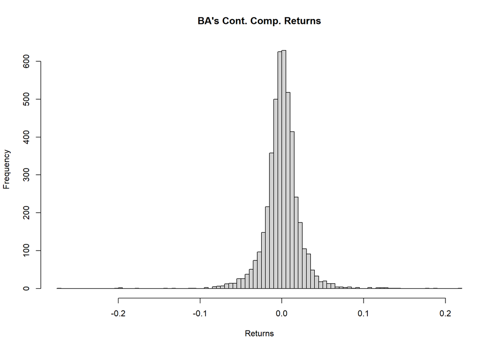

```r
hist(ba.ret, breaks=100, main="BA's Cont. Comp. Returns", xlab="Returns")
```

The distribution is bell-shaped indicating a normal-like distribution. Most returns are clustered near zero.

## Histogram for mondays returns

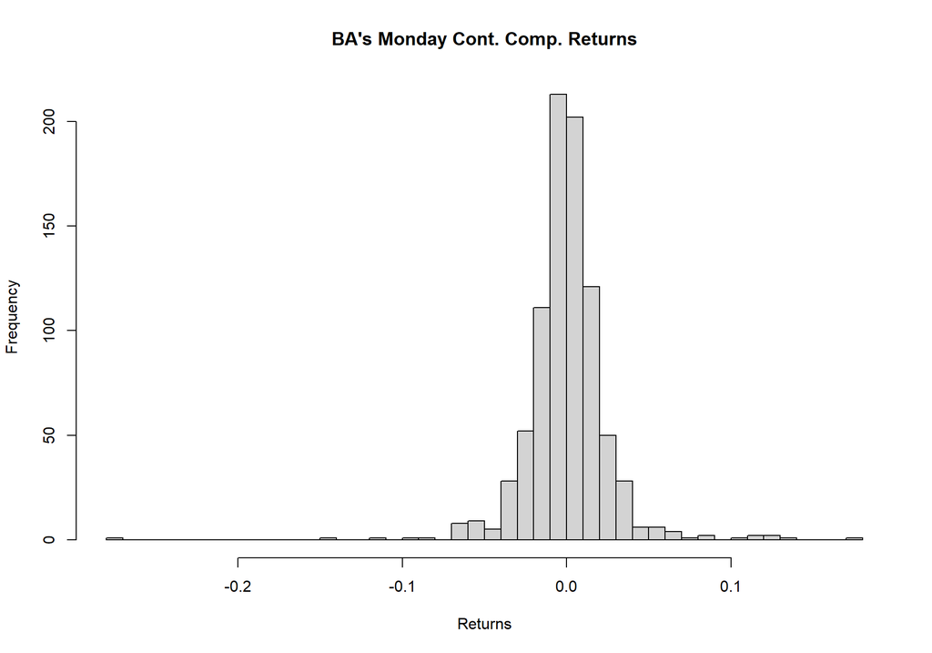

```r
hist(ba.ret[wday(index(ba.ret))==2], breaks=50, main="BA's Monday Cont. Comp. Returns", xlab="Returns")
```

We can the same thing here as well. The distribution is bell-shaped indicating a normal-like distribution. Most returns are clustered near zero.

## Histogram for fridays returns

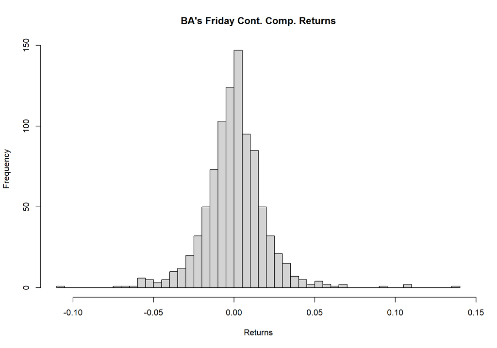

```r
hist(ba.ret[wday(index(ba.ret))==6], breaks=50, main="BA's Friday Cont. Comp. Returns", xlab="Returns")
```

## Empirical Cumulative Distribution of Fridays Return

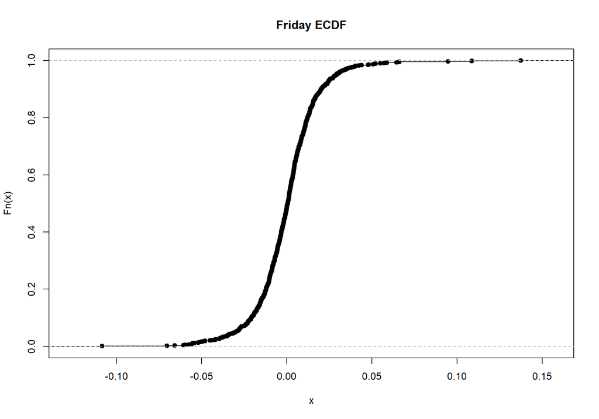

```r
plot(ecdf(as.vector(ba.ret[wday(index(ba.ret))==6])), main="Friday ECDF")
```

## Comparison of Empirical Cumulative Distributions of Monday (red) and Fridays (black) Return

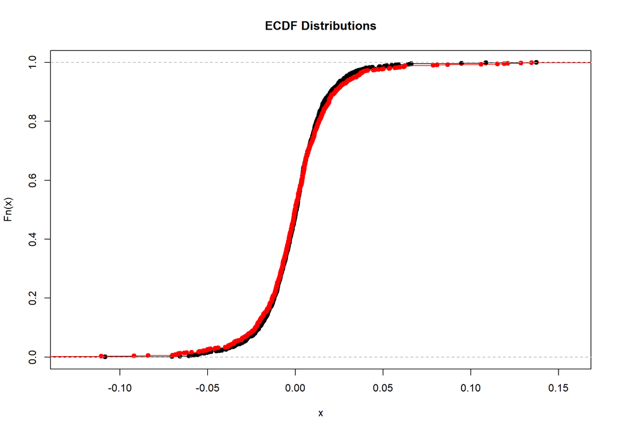

```r
plot(ecdf(as.vector(ba.ret[wday(index(ba.ret))==6])), main="ECDF Distributions")
lines(ecdf(as.vector(ba.ret[wday(index(ba.ret))==2])), col="red")
```

## Mean of the weekday returns

```r
# What about mean returns of weekdays..
mean.ret <- cbind(
mean(ba.ret[wday(index(ba.ret))==2], na.rm=T),
mean(ba.ret[wday(index(ba.ret))==3], na.rm=T),
mean(ba.ret[wday(index(ba.ret))==4], na.rm=T),
mean(ba.ret[wday(index(ba.ret))==5], na.rm=T),
mean(ba.ret[wday(index(ba.ret))==6], na.rm=T))
colnames(mean.ret) <- levels(wday(index(ba.ret), label=T))[2:6]
rownames(mean.ret) <- "Mean Returns"

# Lets see up to 6 digits..
round(mean.ret, 6)
```

```
##                   Pzt      Sal      Çar      Per      Cum
## Mean Returns 0.000189 0.000133 0.000168 0.000363 0.000224
```

## BA Monday Prices Line Chart

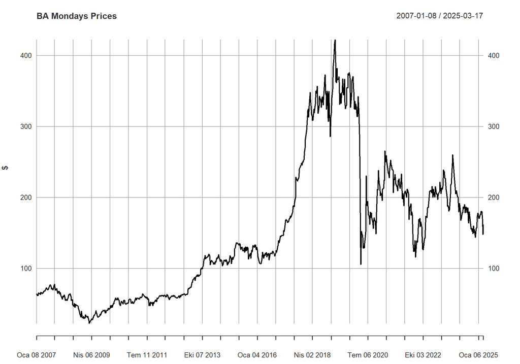

```r
plot(ba[wday(index(ba))==2], main="BA Mondays Prices", ylab="$")
```

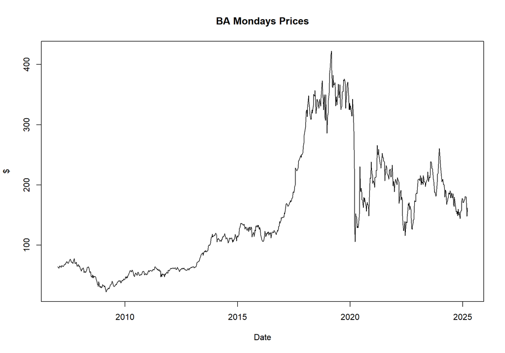

```r
# zoo type..
plot(as.zoo(ba[wday(index(ba))==2]), main="BA Mondays Prices", ylab="$", xlab="Date")
```

We see that before the 2017 it is increasing in its normal trend. Before 2017 its around 100 dollars. After 2017 prices increase exponentially and rises up to 400 dollars. After 2020 prices declines significantly. After 2021 it is increases around 200 dollars.

## Monthly Series

```r
# Convert to monthly series
ba.m <- Ad(to.monthly(BA))
# Get the return series similar to above
ba.mret <- diff(log(ba.m))
# The mean of all montly returns.. (up to 6 digits)
round(mean(ba.mret, na.rm=T), 6)
```

```
## [1] 0.004502
```

```r
# What about the yearly mean returns calculated from monthly returns.. (up to 6 digits).. Seems better than T-Bonds.. Remember utility functions..
round((1+mean(ba.mret, na.rm=T))^12-1, 6)
```

```
## [1] 0.055387
```

```r
# Here is the mean yearly return calculated from data
round(mean(diff(log(Ad(to.yearly(BA)))), na.rm=T), 6)
```

```
## [1] 0.055038
```

```r
# Get some mean return value fo specific months..
head(ba.mret[month(index(ba.mret))==1], na.rm=T)
```

```
##           BA.Adjusted
## Oca 2007           NA
## Oca 2008 -0.050174965
## Oca 2009 -0.008472288
## Oca 2010  0.112905965
## Oca 2011  0.062659638
## Oca 2012  0.011251996
```

```r
# Mean January Returns.. (check your R and OS language for different month labels..)
mean(ba.mret[month(index(ba.mret))==1], na.rm=T)
```

```
## [1] 0.007311363
```

```r
# February..
mean(ba.mret[month(index(ba.mret))==2], na.rm=T)
```

```
## [1] 0.002950708
```

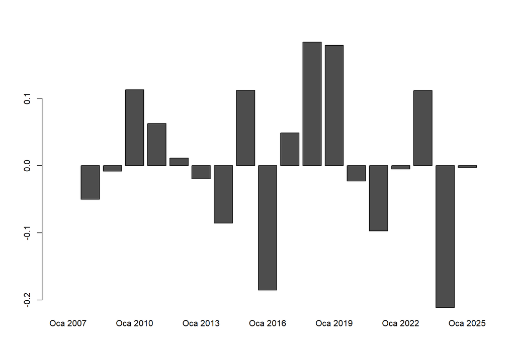

```r
# All January returns since 2007
barplot(ba.mret[month(index(ba.mret))==1])
```

## Comparing Return Distribution

```r
# Compare Mondays and Tuesdays..
ks.test(ba.ret[wday(index(ba.ret))==2], ba.ret[wday(index(ba.ret))==3])
```

```
##
##  Asymptotic two-sample Kolmogorov-Smirnov test
##
## data:  ba.ret[wday(index(ba.ret)) == 2] and ba.ret[wday(index(ba.ret)) == 3]
## D = 0.064044, p-value = 0.05036
## alternative hypothesis: two-sided
```

```r
# Compare Mondays and Fridays..
ks.test(ba.ret[wday(index(ba.ret))==2], ba.ret[wday(index(ba.ret))==6])
```

```
##
##  Asymptotic two-sample Kolmogorov-Smirnov test
##
## data:  ba.ret[wday(index(ba.ret)) == 2] and ba.ret[wday(index(ba.ret)) == 6]
## D = 0.047449, p-value = 0.2706
## alternative hypothesis: two-sided
```

```r
# Let's obtain all.. Create 5*5 matrix.. We use only upper-triangle
# See the structure of ks.test result first..
p.matr <- matrix(rep(0, 5*5), nrow=5)
colnames(p.matr) <- rownames(p.matr) <- levels(wday(index(ba.ret), label=T))[2:6]

for (i in 2:6){
  for (j in i:6){
    p.matr[i-1,j-1] <- ks.test(as.numeric(ba.ret[wday(index(ba.ret))==i]), as.numeric(ba.ret[wday(index(ba.ret))==j]))$p.value
  }
}

# p-vales matrix of  Kolmogorov-Smirnov Tests
round(p.matr, 3)
```

[output not shown]

```r
# Let's obtain all months returns.. Create 12*12 matrix.. We use only upper-triangle
# See the structure of ks.test result first..
pm.matr <- matrix(rep(0, 12*12), nrow=12)
colnames(pm.matr) <- rownames(pm.matr) <- levels(month(index(ba.mret), label=T))

for (i in 1:12){
  for (j in i:12){
    pm.matr[i,j] <- ks.test(as.numeric(ba.mret[month(index(ba.mret))==i]), as.numeric(ba.mret[month(index(ba.mret))==j]))$p.value
  }
}

# p-vales matrix of  Kolmogorov-Smirnov Tests
round(pm.matr, 3)
```

```
##     Oca   Şub   Mar   Nis   May   Haz   Tem   Ağu   Eyl   Eki   Kas   Ara
## Oca   1 0.623 0.995 0.972 0.781 0.781 0.972 0.503 0.781 0.972 0.503 0.503
## Şub   0 1.000 0.808 0.991 0.623 0.587 0.882 0.181 0.870 0.338 0.087 0.960
## Mar   0 0.000 1.000 0.808 0.924 0.703 0.792 0.825 0.808 0.981 0.159 0.273
## Nis   0 0.000 0.000 1.000 1.000 0.972 1.000 0.503 0.972 0.781 0.503 0.972
## May   0 0.000 0.000 0.000 1.000 0.781 0.972 0.503 0.781 0.781 0.503 0.781
## Haz   0 0.000 0.000 0.000 0.000 1.000 0.781 0.781 0.781 0.781 0.132 0.503
## Tem   0 0.000 0.000 0.000 0.000 0.000 1.000 0.275 0.781 0.781 0.781 0.972
## Ağu   0 0.000 0.000 0.000 0.000 0.000 0.000 1.000 0.503 0.972 0.132 0.132
## Eyl   0 0.000 0.000 0.000 0.000 0.000 0.000 0.000 1.000 0.972 0.503 0.781
## Eki   0 0.000 0.000 0.000 0.000 0.000 0.000 0.000 0.000 1.000 0.275 0.275
## Kas   0 0.000 0.000 0.000 0.000 0.000 0.000 0.000 0.000 0.000 1.000 0.275
## Ara   0 0.000 0.000 0.000 0.000 0.000 0.000 0.000 0.000 0.000 0.000 1.000
```